# CaseStudy2 Work Place Attrition & Salary

Joseph Lazarus

2/17/2021

## R Markdown

This R Markdown document is part of SMU’s Master’s in Data Science Program DS 6306 “Doing Data Science.” Student’s are given a data set and asked to make predictions using data science methods and techniques learned in the course. For this case study we are asumming that we have been hired by a company called DDSAnalytics that specializes in talent management. The company wants to gain a competitive edge by providing its customers with accurate predictions regarding attrition (employee turnover) and monthly salary.

We will start by importing the following data for analysis:

CaseStudy2-Data.csv:

1. Later we will import the folowing data sets that will used to make our predictions for the class contest.
- CaseStudy2CompSet No Attritioin.csv
- CaseStudy2CompSet No Solary.csv

```r
#Load Libraries needed for analysis
library(dplyr)
library(tidyverse)
library(visdat)
library(GGally)
```

```r
library(ggplot2)
library(skimr)
library(stringr)
library(corrplot)
library(ggplot2)
library(ggthemes)
library(vcd)
library(rpart.plot)
library(BBmisc)
```

Load Theme for plots

```r
#~~~~~~~~~~~~~~~~~~~~~~~~~~~~~~~~~~~~~~~~~~~~~~~~~~~~~~~~~~~~~~~~~~~~~~~~~~~~~~~
#                    Set Theme for Plots
#~~~~~~~~~~~~~~~~~~~~~~~~~~~~~~~~~~~~~~~~~~~~~~~~~~~~~~~~~~~~~~~~~~~~~~~~~~~~~~~
theme_set(theme_fivethirtyeight())
theme_update(axis.title = element_text()) #the default for fivethirtyeight is to not show axis labels, this removes that default so we can choose to specify and display axis titles
theme_update(plot.title = element_text(hjust = 0.5)) # changing default to center all titles
```

#~~~~~~~~~~~~~~~~~~~~~~~~~~~~~~~~~~~~~~~~~~~~~~~~~~~~~~~~~~~~~~~~~~~~~~~~~~~~~~~ # Data Preparation #~~~~~~~~~~~~~~~~~~~~~~~~~~~~~~~~~~~~~~~~~~~~~~~~~~~~~~~~~~~~~~~~~~~~~~~~~~~~~~~

```r
df <- read.csv("https://raw.githubusercontent.com/JosephLazarus/CaseStudy2DDS_Work_Place_Attrition/main/the_data_folder/CaseStudy2-data.csv")

head(df)
```

```
##   ID Age Attrition    BusinessTravel DailyRate             Department
## 1  1  32        No     Travel_Rarely       117                  Sales
## 2  2  40        No     Travel_Rarely      1308 Research & Development
## 3  3  35        No Travel_Frequently       200 Research & Development
## 4  4  32        No     Travel_Rarely       801                  Sales
## 5  5  24        No Travel_Frequently       567 Research & Development
## 6  6  27        No Travel_Frequently       294 Research & Development
##   DistanceFromHome Education   EducationField EmployeeCount EmployeeNumber
## 1               13         4    Life Sciences             1            859
## 2               14         3          Medical             1           1128
## 3               18         2    Life Sciences             1           1412
## 4                1         4        Marketing             1           2016
## 5                2         1 Technical Degree             1           1646
## 6               10         2    Life Sciences             1            733
##   EnvironmentSatisfaction Gender HourlyRate JobInvolvement JobLevel
```

[output cut: 41 more lines]

```r
# attach df to read variavles locally
attach(df)
#explore data structure

str(df)
```

```
## 'data.frame':    870 obs. of  36 variables:
##  $ ID                      : int  1 2 3 4 5 6 7 8 9 10 ...
##  $ Age                     : int  32 40 35 32 24 27 41 37 34 34 ...
##  $ Attrition               : chr  "No" "No" "No" "No" ...
##  $ BusinessTravel          : chr  "Travel_Rarely" "Travel_Rarely" "Travel_Frequently" "Travel_Rarely" ...
##  $ DailyRate               : int  117 1308 200 801 567 294 1283 309 1333 653 ...
##  $ Department              : chr  "Sales" "Research & Development" "Research & Development" "Sales" ...
##  $ DistanceFromHome        : int  13 14 18 1 2 10 5 10 10 10 ...
##  $ Education               : int  4 3 2 4 1 2 5 4 4 4 ...
##  $ EducationField          : chr  "Life Sciences" "Medical" "Life Sciences" "Marketing" ...
##  $ EmployeeCount           : int  1 1 1 1 1 1 1 1 1 1 ...
##  $ EmployeeNumber          : int  859 1128 1412 2016 1646 733 1448 1105 1055 1597 ...
##  $ EnvironmentSatisfaction : int  2 3 3 3 1 4 2 4 3 4 ...
##  $ Gender                  : chr  "Male" "Male" "Male" "Female" ...
##  $ HourlyRate              : int  73 44 60 48 32 32 90 88 87 92 ...
```

[output cut: 22 more lines]

```r
dim(df) #870 X 36
```

```
## [1] 870  36
```

```r
which(is.na(df)) # no NA's I don't believe it
```

```
## integer(0)
```

```r
colSums(is.na(df)) # still no NA's I believe it now
```

```
##                       ID                      Age                Attrition
##                        0                        0                        0
##           BusinessTravel                DailyRate               Department
##                        0                        0                        0
##         DistanceFromHome                Education           EducationField
##                        0                        0                        0
##            EmployeeCount           EmployeeNumber  EnvironmentSatisfaction
##                        0                        0                        0
##                   Gender               HourlyRate           JobInvolvement
##                        0                        0                        0
##                 JobLevel                  JobRole          JobSatisfaction
##                        0                        0                        0
##            MaritalStatus            MonthlyIncome              MonthlyRate
##                        0                        0                        0
##       NumCompaniesWorked                   Over18                 OverTime
##                        0                        0                        0
##        PercentSalaryHike        PerformanceRating RelationshipSatisfaction
##                        0                        0                        0
##            StandardHours         StockOptionLevel        TotalWorkingYears
##                        0                        0                        0
##    TrainingTimesLastYear          WorkLifeBalance           YearsAtCompany
##                        0                        0                        0
##       YearsInCurrentRole  YearsSinceLastPromotion     YearsWithCurrManager
##                        0                        0                        0
```

```r
# 870 obs x 36 variables
# no NA's

summary(df)
```

```
##        ID             Age         Attrition         BusinessTravel
##  Min.   :  1.0   Min.   :18.00   Length:870         Length:870
##  1st Qu.:218.2   1st Qu.:30.00   Class :character   Class :character
##  Median :435.5   Median :35.00   Mode  :character   Mode  :character
##  Mean   :435.5   Mean   :36.83
##  3rd Qu.:652.8   3rd Qu.:43.00
##  Max.   :870.0   Max.   :60.00
##    DailyRate       Department        DistanceFromHome   Education
##  Min.   : 103.0   Length:870         Min.   : 1.000   Min.   :1.000
##  1st Qu.: 472.5   Class :character   1st Qu.: 2.000   1st Qu.:2.000
##  Median : 817.5   Mode  :character   Median : 7.000   Median :3.000
##  Mean   : 815.2                      Mean   : 9.339   Mean   :2.901
##  3rd Qu.:1165.8                      3rd Qu.:14.000   3rd Qu.:4.000
##  Max.   :1499.0                      Max.   :29.000   Max.   :5.000
##  EducationField     EmployeeCount EmployeeNumber   EnvironmentSatisfaction
##  Length:870         Min.   :1     Min.   :   1.0   Min.   :1.000
##  Class :character   1st Qu.:1     1st Qu.: 477.2   1st Qu.:2.000
##  Mode  :character   Median :1     Median :1039.0   Median :3.000
##                     Mean   :1     Mean   :1029.8   Mean   :2.701
##                     3rd Qu.:1     3rd Qu.:1561.5   3rd Qu.:4.000
##                     Max.   :1     Max.   :2064.0   Max.   :4.000
##     Gender            HourlyRate     JobInvolvement     JobLevel
##  Length:870         Min.   : 30.00   Min.   :1.000   Min.   :1.000
##  Class :character   1st Qu.: 48.00   1st Qu.:2.000   1st Qu.:1.000
##  Mode  :character   Median : 66.00   Median :3.000   Median :2.000
##                     Mean   : 65.61   Mean   :2.723   Mean   :2.039
##                     3rd Qu.: 83.00   3rd Qu.:3.000   3rd Qu.:3.000
##                     Max.   :100.00   Max.   :4.000   Max.   :5.000
##    JobRole          JobSatisfaction MaritalStatus      MonthlyIncome
##  Length:870         Min.   :1.000   Length:870         Min.   : 1081
##  Class :character   1st Qu.:2.000   Class :character   1st Qu.: 2840
##  Mode  :character   Median :3.000   Mode  :character   Median : 4946
##                     Mean   :2.709                      Mean   : 6390
##                     3rd Qu.:4.000                      3rd Qu.: 8182
##                     Max.   :4.000                      Max.   :19999
##   MonthlyRate    NumCompaniesWorked    Over18            OverTime
##  Min.   : 2094   Min.   :0.000      Length:870         Length:870
##  1st Qu.: 8092   1st Qu.:1.000      Class :character   Class :character
##  Median :14074   Median :2.000      Mode  :character   Mode  :character
##  Mean   :14326   Mean   :2.728
```

[output cut: 15 more lines]

```
##  Max.   :3.0000   Max.   :40.00     Max.   :6.000         Max.   :4.000
##  YearsAtCompany   YearsInCurrentRole YearsSinceLastPromotion
##  Min.   : 0.000   Min.   : 0.000     Min.   : 0.000
##  1st Qu.: 3.000   1st Qu.: 2.000     1st Qu.: 0.000
##  Median : 5.000   Median : 3.000     Median : 1.000
##  Mean   : 6.962   Mean   : 4.205     Mean   : 2.169
##  3rd Qu.:10.000   3rd Qu.: 7.000     3rd Qu.: 3.000
##  Max.   :40.000   Max.   :18.000     Max.   :15.000
##  YearsWithCurrManager
##  Min.   : 0.00
##  1st Qu.: 2.00
##  Median : 3.00
##  Mean   : 4.14
##  3rd Qu.: 7.00
##  Max.   :17.00
```

```r
library(skimr)
skim(df) #over18  Employeecount Standardhours have no variation
```

Data summary

| Name | df |
| --- | --- |
| Number of rows | 870 |
| Number of columns | 36 |
| _______________________ |  |
| Column type frequency: |  |
| character | 9 |
| numeric | 27 |
| ________________________ |  |
| Group variables | None |

**Variable type: character**

| skim_variable | n_missing | complete_rate | min | max | empty | n_unique | whitespace |
| --- | --- | --- | --- | --- | --- | --- | --- |
| Attrition | 0 | 1 | 2 | 3 | 0 | 2 | 0 |
| BusinessTravel | 0 | 1 | 10 | 17 | 0 | 3 | 0 |
| Department | 0 | 1 | 5 | 22 | 0 | 3 | 0 |
| EducationField | 0 | 1 | 5 | 16 | 0 | 6 | 0 |
| Gender | 0 | 1 | 4 | 6 | 0 | 2 | 0 |
| JobRole | 0 | 1 | 7 | 25 | 0 | 9 | 0 |
| MaritalStatus | 0 | 1 | 6 | 8 | 0 | 3 | 0 |
| Over18 | 0 | 1 | 1 | 1 | 0 | 1 | 0 |
| OverTime | 0 | 1 | 2 | 3 | 0 | 2 | 0 |

**Variable type: numeric**

| skim_variable | n_missing | complete_rate | mean | sd | p0 | p25 | p50 | p75 | p100 | hist |
| --- | --- | --- | --- | --- | --- | --- | --- | --- | --- | --- |
| ID | 0 | 1 | 435.50 | 251.29 | 1 | 218.25 | 435.5 | 652.75 | 870 | ▇▇▇▇▇ |
| Age | 0 | 1 | 36.83 | 8.93 | 18 | 30.00 | 35.0 | 43.00 | 60 | ▂▇▇▃▂ |
| DailyRate | 0 | 1 | 815.23 | 401.12 | 103 | 472.50 | 817.5 | 1165.75 | 1499 | ▇▇▇▇▇ |
| DistanceFromHome | 0 | 1 | 9.34 | 8.14 | 1 | 2.00 | 7.0 | 14.00 | 29 | ▇▅▂▂▂ |
| Education | 0 | 1 | 2.90 | 1.02 | 1 | 2.00 | 3.0 | 4.00 | 5 | ▂▅▇▆▁ |
| EmployeeCount | 0 | 1 | 1.00 | 0.00 | 1 | 1.00 | 1.0 | 1.00 | 1 | ▁▁▇▁▁ |
| EmployeeNumber | 0 | 1 | 1029.83 | 604.79 | 1 | 477.25 | 1039.0 | 1561.50 | 2064 | ▇▇▇▇▇ |
| EnvironmentSatisfaction | 0 | 1 | 2.70 | 1.10 | 1 | 2.00 | 3.0 | 4.00 | 4 | ▅▆▁▇▇ |
| HourlyRate | 0 | 1 | 65.61 | 20.13 | 30 | 48.00 | 66.0 | 83.00 | 100 | ▇▇▆▇▇ |
| JobInvolvement | 0 | 1 | 2.72 | 0.70 | 1 | 2.00 | 3.0 | 3.00 | 4 | ▁▃▁▇▁ |
| JobLevel | 0 | 1 | 2.04 | 1.09 | 1 | 1.00 | 2.0 | 3.00 | 5 | ▇▇▃▂▁ |
| JobSatisfaction | 0 | 1 | 2.71 | 1.11 | 1 | 2.00 | 3.0 | 4.00 | 4 | ▅▅▁▇▇ |
| MonthlyIncome | 0 | 1 | 6390.26 | 4597.70 | 1081 | 2839.50 | 4945.5 | 8182.00 | 19999 | ▇▅▂▁▁ |
| MonthlyRate | 0 | 1 | 14325.62 | 7108.38 | 2094 | 8092.00 | 14074.5 | 20456.25 | 26997 | ▇▇▇▇▇ |
| NumCompaniesWorked | 0 | 1 | 2.73 | 2.52 | 0 | 1.00 | 2.0 | 4.00 | 9 | ▇▃▂▂▁ |
| PercentSalaryHike | 0 | 1 | 15.20 | 3.68 | 11 | 12.00 | 14.0 | 18.00 | 25 | ▇▅▃▂▁ |
| PerformanceRating | 0 | 1 | 3.15 | 0.36 | 3 | 3.00 | 3.0 | 3.00 | 4 | ▇▁▁▁▂ |
| RelationshipSatisfaction | 0 | 1 | 2.71 | 1.10 | 1 | 2.00 | 3.0 | 4.00 | 4 | ▅▅▁▇▇ |
| StandardHours | 0 | 1 | 80.00 | 0.00 | 80 | 80.00 | 80.0 | 80.00 | 80 | ▁▁▇▁▁ |
| StockOptionLevel | 0 | 1 | 0.78 | 0.86 | 0 | 0.00 | 1.0 | 1.00 | 3 | ▇▇▁▂▁ |
| TotalWorkingYears | 0 | 1 | 11.05 | 7.51 | 0 | 6.00 | 10.0 | 15.00 | 40 | ▇▇▂▁▁ |
| TrainingTimesLastYear | 0 | 1 | 2.83 | 1.27 | 0 | 2.00 | 3.0 | 3.00 | 6 | ▂▇▇▂▃ |
| WorkLifeBalance | 0 | 1 | 2.78 | 0.71 | 1 | 2.00 | 3.0 | 3.00 | 4 | ▁▃▁▇▂ |
| YearsAtCompany | 0 | 1 | 6.96 | 6.02 | 0 | 3.00 | 5.0 | 10.00 | 40 | ▇▃▁▁▁ |
| YearsInCurrentRole | 0 | 1 | 4.20 | 3.64 | 0 | 2.00 | 3.0 | 7.00 | 18 | ▇▃▂▁▁ |
| YearsSinceLastPromotion | 0 | 1 | 2.17 | 3.19 | 0 | 0.00 | 1.0 | 3.00 | 15 | ▇▁▁▁▁ |
| YearsWithCurrManager | 0 | 1 | 4.14 | 3.57 | 0 | 2.00 | 3.0 | 7.00 | 17 | ▇▂▅▁▁ |

```r
library(dplyr)
#removing these variables from the data set
df <- select(df, -c(Over18, EmployeeCount, StandardHours, EmployeeNumber))

#convert char variables to factors
var_facs <- c("Attrition","EducationField","MaritalStatus","BusinessTravel","JobRole", "Department", "OverTime", "Gender")
df[,var_facs] <- lapply(df[,var_facs] , factor, ordered = FALSE)

#convert those factors to (i) integers for later
df$iJobRole <- as.integer(df$JobRole)
df$iDepartment <- as.integer(df$Department)
df$iMaritalStatus <- as.integer(df$MaritalStatus)
df$iBusinessTravel <- as.integer(df$BusinessTravel)
df$iEducation <- as.integer(df$Education)
df$iAttrition <- as.integer(df$Attrition)

#quick check of our data
str(df)
```

```
## 'data.frame':    870 obs. of  38 variables:
##  $ ID                      : int  1 2 3 4 5 6 7 8 9 10 ...
##  $ Age                     : int  32 40 35 32 24 27 41 37 34 34 ...
##  $ Attrition               : Factor w/ 2 levels "No","Yes": 1 1 1 1 1 1 1 1 1 1 ...
##  $ BusinessTravel          : Factor w/ 3 levels "Non-Travel","Travel_Frequently",..: 3 3 2 3 2 2 3 3 3 2 ...
##  $ DailyRate               : int  117 1308 200 801 567 294 1283 309 1333 653 ...
##  $ Department              : Factor w/ 3 levels "Human Resources",..: 3 2 2 3 2 2 2 3 3 2 ...
##  $ DistanceFromHome        : int  13 14 18 1 2 10 5 10 10 10 ...
##  $ Education               : int  4 3 2 4 1 2 5 4 4 4 ...
##  $ EducationField          : Factor w/ 6 levels "Human Resources",..: 2 4 2 3 6 2 4 2 2 6 ...
##  $ EnvironmentSatisfaction : int  2 3 3 3 1 4 2 4 3 4 ...
##  $ Gender                  : Factor w/ 2 levels "Female","Male": 2 2 2 1 1 2 2 1 1 2 ...
##  $ HourlyRate              : int  73 44 60 48 32 32 90 88 87 92 ...
##  $ JobInvolvement          : int  3 2 3 3 3 3 4 2 3 2 ...
##  $ JobLevel                : int  2 5 3 3 1 3 1 2 1 2 ...
```

[output cut: 24 more lines]

#~~~~~~~~~~~~~~~~~~~~~~~~~~~~~~~~~~~~~~~~~~~~~~~~~~~~~~~~~~~~~~~~~~~~~~~~~~~~~~~ # Exploratoration into Data #~~~~~~~~~~~~~~~~~~~~~~~~~~~~~~~~~~~~~~~~~~~~~~~~~~~~~~~~~~~~~~~~~~~~~~~~~~~~~~~

```r
#Look at Age
quantile(Age)
```

```
##   0%  25%  50%  75% 100%
##   18   30   35   43   60
```

```r
tapply(Age, Attrition, mean)
```

```
##       No      Yes
## 37.41233 33.78571
```

```r
#NumCompaniesWorked
quantile(NumCompaniesWorked)
```

```
##   0%  25%  50%  75% 100%
##    0    1    2    4    9
```

```r
tapply(NumCompaniesWorked, Attrition, mean)
```

```
##       No      Yes
## 2.660274 3.078571
```

```r
#percent SalaryHike
quantile(PercentSalaryHike)
```

```
##   0%  25%  50%  75% 100%
##   11   12   14   18   25
```

```r
tapply(PercentSalaryHike, Attrition, mean)
```

```
##       No      Yes
## 15.17534 15.32857
```

```r
#total Working Years
quantile(TotalWorkingYears)
```

```
##   0%  25%  50%  75% 100%
##    0    6   10   15   40
```

```r
tapply(TotalWorkingYears, Attrition, mean)
```

```
##        No       Yes
## 11.602740  8.185714
```

```r
#Monthly Income
quantile(MonthlyIncome)
```

```
##      0%     25%     50%     75%    100%
##  1081.0  2839.5  4945.5  8182.0 19999.0
```

```r
tapply(MonthlyIncome, Attrition, mean)
```

```
##       No      Yes
## 6702.000 4764.786
```

```r
#YearsInCurrentRole
quantile(YearsInCurrentRole)
```

```
##   0%  25%  50%  75% 100%
##    0    2    3    7   18
```

```r
tapply(YearsInCurrentRole, Attrition, mean)
```

```
##       No      Yes
## 4.453425 2.907143
```

```r
#years with Manager
quantile(YearsWithCurrManager)
```

```
##   0%  25%  50%  75% 100%
##    0    2    3    7   17
```

```r
tapply(YearsWithCurrManager, Attrition, mean)
```

```
##       No      Yes
## 4.369863 2.942857
```

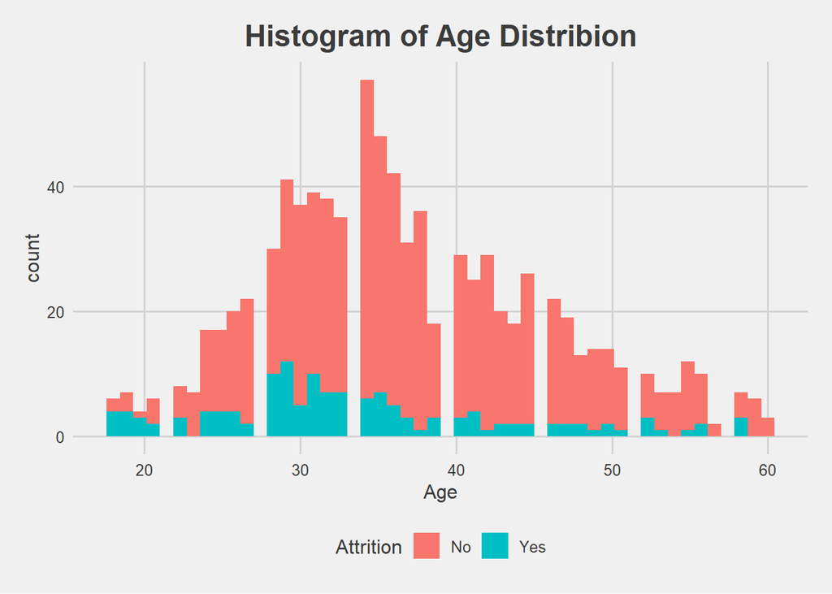

```r
library(ggplot2)
#observed a concentration in younger employees Lets plot this
df %>% ggplot(aes(x = Age)) + geom_histogram(aes(fill = Attrition), bins = 50) + ggtitle("Histogram of Age Distribion")
```

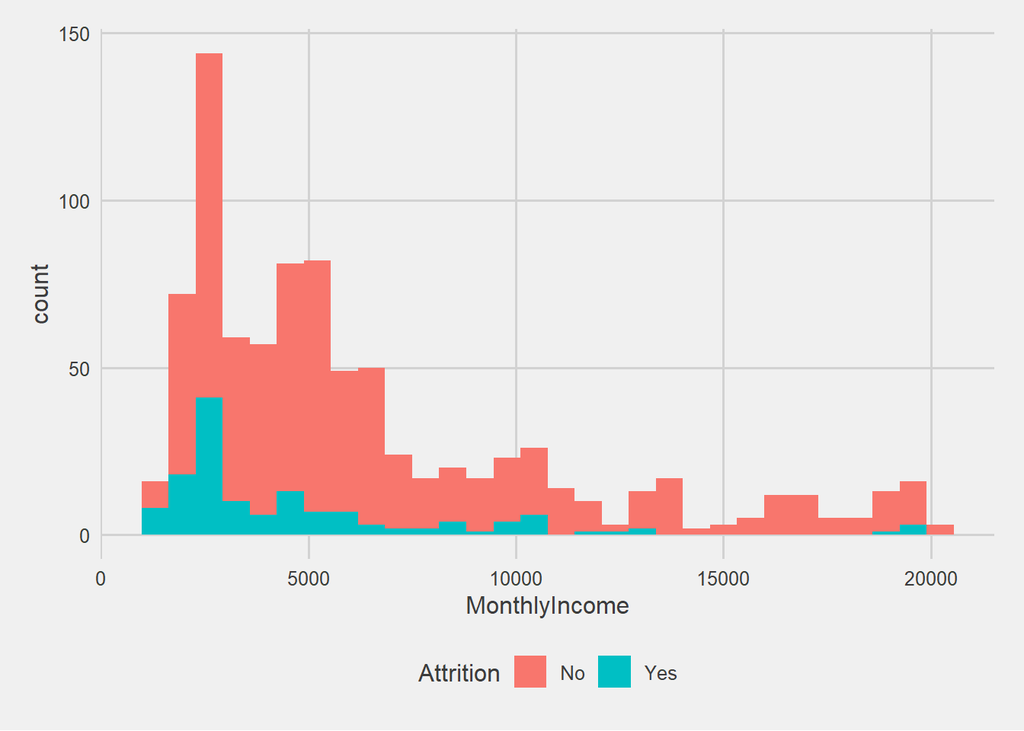

```r
#Monthlyincome could be important too, High paid employees may not want to leave
df %>% ggplot(aes(x=MonthlyIncome)) + geom_histogram(aes(fill=Attrition))
```

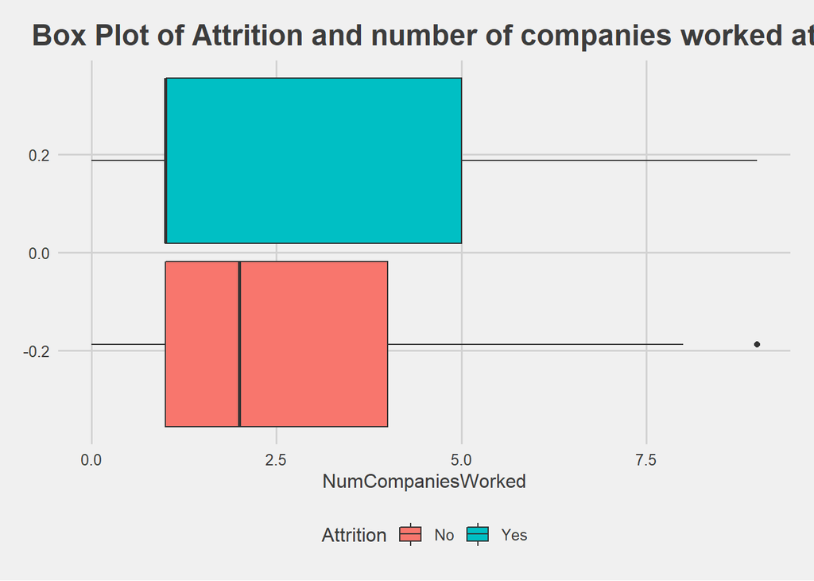

```r
#If the employee worked at many companies past performance might predict future outcomes
df %>% ggplot(aes (x= NumCompaniesWorked)) + geom_boxplot(aes(fill = Attrition)) + ggtitle("Box Plot of Attrition and number of companies worked at")
```

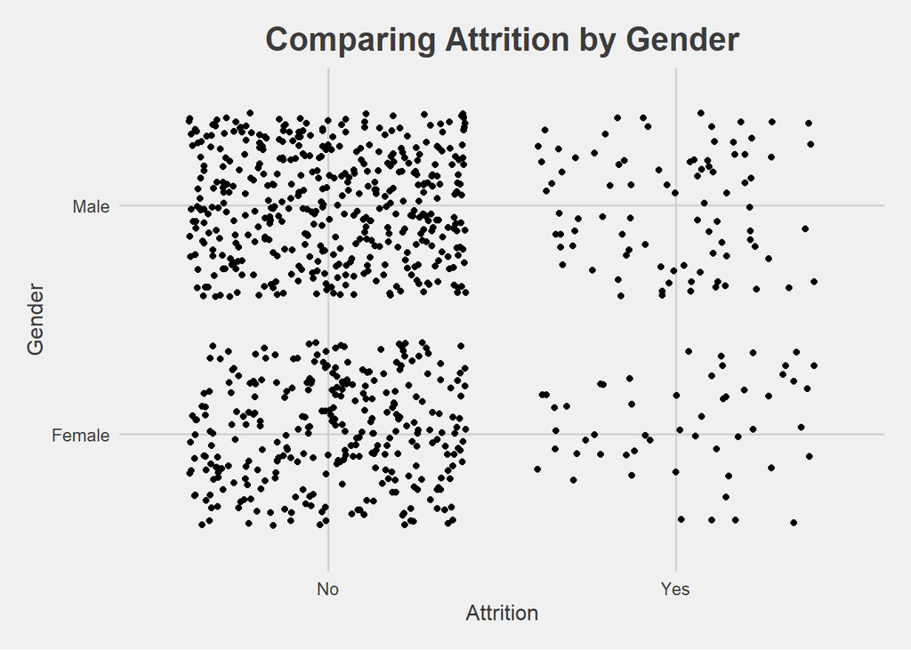

```r
df %>% ggplot(aes(x=Attrition, Gender)) + geom_jitter() + ggtitle("Comparing Attrition by Gender")
```

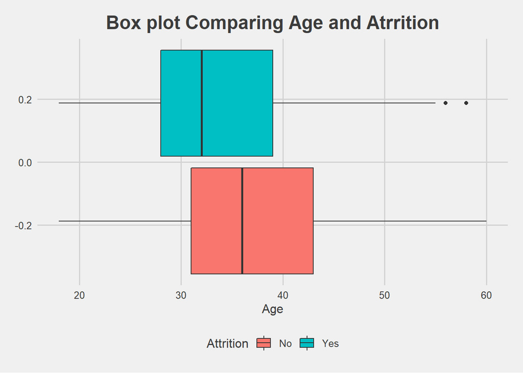

```r
df %>% ggplot(aes (x= Age)) + geom_boxplot(aes(fill = Attrition)) +ggtitle("Box plot Comparing Age and Atrrition")
```

```r
#I'd like to create groups by factors that we created earlier based off what we saw in the graph and the quantiles that i found important. That might help models make predictions.

# We know mean age for attrition to be  is
# No      Yes
# 37.412 33.785

#create Factors for age group

df <- mutate(df, Age.Group = as.factor(case_when(Age <= 22 ~ 'Undergrad',
                                   Age <= 34 ~'Young-Professional',
                                   Age <= 44 ~ 'Veteran',
                                   Age >= 45 ~ 'Senior')))
#use quantiles to pick income brackets
quantile(MonthlyIncome)
```

```
##      0%     25%     50%     75%    100%
##  1081.0  2839.5  4945.5  8182.0 19999.0
```

```r
df <- mutate(df, MonthlyIncome.Group = as.factor(case_when(MonthlyIncome <= 2800 ~ 'Low',
                                     MonthlyIncome <=4999 ~ 'Avg',
                                     MonthlyIncome <=7999 ~ 'Above.Avg',
                                     MonthlyIncome >=8000 ~ 'High')))

quantile(YearsInCurrentRole)
```

```
##   0%  25%  50%  75% 100%
##    0    2    3    7   18
```

```r
tapply(YearsInCurrentRole, Attrition, mean)
```

```
##       No      Yes
## 4.453425 2.907143
```

```r
df <- mutate(df, YearsWithCurrManager.Group = as.factor(case_when(YearsWithCurrManager <= 2 ~ "Lessthan2",
                                          YearsWithCurrManager <= 4 ~ "2thru4",
                                          YearsWithCurrManager <= 6.9 ~ "4thru6",
                                          YearsWithCurrManager >= 7~ "7&above")))

quantile(YearsInCurrentRole)
```

```
##   0%  25%  50%  75% 100%
##    0    2    3    7   18
```

```r
tapply(YearsInCurrentRole, Attrition, mean)
```

```
##       No      Yes
## 4.453425 2.907143
```

```r
df <-  mutate(df, YearsInCurrentRole.Group = as.factor(case_when(YearsInCurrentRole <=2 ~ "Lessthan2",
                                          YearsInCurrentRole <= 3 ~ "Lessthan3",
                                          YearsInCurrentRole <= 4 ~ "Lessthan4",
                                          YearsInCurrentRole >4 ~ "5&above")))


quantile(YearsAtCompany)
```

```
##   0%  25%  50%  75% 100%
##    0    3    5   10   40
```

```r
tapply(YearsAtCompany, Attrition,mean)
```

```
##       No      Yes
## 7.301370 5.192857
```

```r
df <- mutate(df, YearsAtCompany.Group = as.factor(case_when(YearsAtCompany <= 3 ~ "LessThan3",
                                            YearsAtCompany <= 5 ~"3thru5",
                                            YearsAtCompany <= 10 ~"5thru10",
                                            YearsAtCompany > 10 ~"10&above")))



#chceck for gaps
which(is.na(df))
```

```
## integer(0)
```

```r
str(df)
```

```
## 'data.frame':    870 obs. of  43 variables:
##  $ ID                        : int  1 2 3 4 5 6 7 8 9 10 ...
##  $ Age                       : int  32 40 35 32 24 27 41 37 34 34 ...
##  $ Attrition                 : Factor w/ 2 levels "No","Yes": 1 1 1 1 1 1 1 1 1 1 ...
##  $ BusinessTravel            : Factor w/ 3 levels "Non-Travel","Travel_Frequently",..: 3 3 2 3 2 2 3 3 3 2 ...
##  $ DailyRate                 : int  117 1308 200 801 567 294 1283 309 1333 653 ...
##  $ Department                : Factor w/ 3 levels "Human Resources",..: 3 2 2 3 2 2 2 3 3 2 ...
##  $ DistanceFromHome          : int  13 14 18 1 2 10 5 10 10 10 ...
##  $ Education                 : int  4 3 2 4 1 2 5 4 4 4 ...
##  $ EducationField            : Factor w/ 6 levels "Human Resources",..: 2 4 2 3 6 2 4 2 2 6 ...
##  $ EnvironmentSatisfaction   : int  2 3 3 3 1 4 2 4 3 4 ...
##  $ Gender                    : Factor w/ 2 levels "Female","Male": 2 2 2 1 1 2 2 1 1 2 ...
##  $ HourlyRate                : int  73 44 60 48 32 32 90 88 87 92 ...
##  $ JobInvolvement            : int  3 2 3 3 3 3 4 2 3 2 ...
##  $ JobLevel                  : int  2 5 3 3 1 3 1 2 1 2 ...
```

[output cut: 29 more lines]

```r
length(df)
```

```
## [1] 43
```

```r
#since number of companies worked at prior lets explore further create New variable of time spent in previous jobs subtratct total work years from years at company divide by number of companies worked for
df$time.at.past.job <- ifelse(df$NumCompaniesWorked!=0, df$TotalWorkingYears-df$YearsAtCompany/df$NumCompaniesWorked,0)

library(BBmisc)
#found this column to not enhance the models unitil i normalized it
df$ntime.at.past.job <- normalize(df$time.at.past.job, method = "standardize", margin = 1L, on.constant ="quiet" )
         #df$ntime.at.past.job
```

#~~~~~~~~~~~~~~~~~~~~~~~~~~~~~~~~~~~~~~~~~~~~~~~~~~~~~~~~~~~~~~~~~~~~~~~~~~~~~~~ # Prepare data for Modeling Train Test SPlit #~~~~~~~~~~~~~~~~~~~~~~~~~~~~~~~~~~~~~~~~~~~~~~~~~~~~~~~~~~~~~~~~~~~~~~~~~~~~~~~

```r
detach("package:BBmisc")

#notice I've made attrition the first column. That makes it easy to pull out for our train/test/splits when modeling. ID isn't in here but will add it back at the end for our validation / competition.

#getting : object 'MonthlyIncome' not found add in monthly income
#did not find it to be helpful in the knn analysis
# taking these out for fun   2/171625

#dat <- select(df, c(3,2,5,7,8,10, 12, 13, 14, 16, 18, 20, 21, 22, 23, 24, 25, 26, 27, 29, 30, 31, 44, 39, 40, 43))
library(dplyr)
#dat <- select(df, c("Attrition", "Age", "Department", "EnvironmentSatisfaction", "NumCompaniesWorked", "JobInvolvement","JobLevel", "JobSatisfaction", "iMaritalStatus","MonthlyIncome", "OverTime","StockOptionLevel", "TotalWorkingYears", "YearsAtCompany", "YearsInCurrentRole", "YearsWithCurrManager" ,"YearsInCurrentRole.Group", "YearsAtCompany.Group", "MonthlyIncome"))

dat <- select(df,c("Attrition","Age.Group", "DistanceFromHome", "MonthlyIncome.Group", "TotalWorkingYears", "OverTime", "YearsAtCompany", "StockOptionLevel", "JobRole", "JobLevel", "JobInvolvement", "Education", "EnvironmentSatisfaction", "WorkLifeBalance", "YearsInCurrentRole", "YearsAtCompany.Group",  "YearsInCurrentRole", "YearsWithCurrManager"))


set.seed(43) # was 31 chainging to another prime

sample_size = round(nrow(dat)*.70) # setting what is 70%
index <- sample(seq_len(nrow(dat)), size = sample_size)

training <- dat[index, ]
test <- dat[-index, ]

dim(dat)
```

```
## [1] 870  17
```

```r
dim(training)
```

```
## [1] 609  17
```

```r
dim(test)
```

```
## [1] 261  17
```

```r
str(training)
```

```
## 'data.frame':    609 obs. of  17 variables:
##  $ Attrition              : Factor w/ 2 levels "No","Yes": 1 1 1 1 1 1 1 1 1 1 ...
##  $ Age.Group              : Factor w/ 4 levels "Senior","Undergrad",..: 3 3 4 4 4 3 1 3 4 4 ...
##  $ DistanceFromHome       : int  9 11 8 24 5 2 29 1 10 3 ...
##  $ MonthlyIncome.Group    : Factor w/ 4 levels "Above.Avg","Avg",..: 3 4 4 2 2 3 2 1 2 1 ...
##  $ TotalWorkingYears      : int  24 5 8 6 7 20 9 10 5 6 ...
##  $ OverTime               : Factor w/ 2 levels "No","Yes": 1 2 1 1 2 1 1 1 2 1 ...
##  $ YearsAtCompany         : int  1 2 3 4 6 19 6 9 5 2 ...
##  $ StockOptionLevel       : int  0 1 0 0 2 0 0 0 1 0 ...
##  $ JobRole                : Factor w/ 9 levels "Healthcare Representative",..: 4 3 2 3 7 1 7 1 7 8 ...
##  $ JobLevel               : int  5 1 1 1 1 3 1 2 1 2 ...
##  $ JobInvolvement         : int  2 3 4 3 4 3 3 4 3 1 ...
##  $ Education              : int  2 4 2 3 2 4 3 4 4 2 ...
##  $ EnvironmentSatisfaction: int  4 4 4 4 1 3 3 2 4 4 ...
##  $ WorkLifeBalance        : int  3 3 3 3 2 3 2 2 4 3 ...
##  $ YearsInCurrentRole     : int  0 2 2 3 2 6 5 7 3 2 ...
##  $ YearsAtCompany.Group   : Factor w/ 4 levels "10&above","3thru5",..: 4 4 4 2 3 1 3 3 2 4 ...
##  $ YearsWithCurrManager   : int  1 2 2 2 5 8 3 8 0 2 ...
```

```r
detach("package:dplyr")
detach("package:stringr")
detach("package:tidyverse")
```

#~~~~~~~~~~~~~~~~~~~~~~~~~~~~~~~~~~~~~~~~~~~~~~~~~~~~~~~~~~~~~~~~~~~~~~~~~~~~~~~ # find important Variables #~~~~~~~~~~~~~~~~~~~~~~~~~~~~~~~~~~~~~~~~~~~~~~~~~~~~~~~~~~~~~~~~~~~~~~~~~~~~~~~

```r
#This was an interative step between modeling data preparation and EDA as well.

library(pROC)
library(caret)
roc_imp <- filterVarImp(x = training[-1], y = training$Attrition)
head(roc_imp)
```

```
##                            No       Yes
## Age.Group           0.5103284 0.5103284
## DistanceFromHome    0.5786201 0.5786201
## MonthlyIncome.Group 0.6164635 0.6164635
## TotalWorkingYears   0.6683950 0.6683950
## OverTime            0.6629622 0.6629622
## YearsAtCompany      0.6513220 0.6513220
```

```r
roc_imp
```

```
##                                No       Yes
## Age.Group               0.5103284 0.5103284
## DistanceFromHome        0.5786201 0.5786201
## MonthlyIncome.Group     0.6164635 0.6164635
## TotalWorkingYears       0.6683950 0.6683950
## OverTime                0.6629622 0.6629622
## YearsAtCompany          0.6513220 0.6513220
## StockOptionLevel        0.6624561 0.6624561
## JobRole                 0.5880397 0.5880397
## JobLevel                0.6551126 0.6551126
## JobInvolvement          0.6287647 0.6287647
## Education               0.5766267 0.5766267
## EnvironmentSatisfaction 0.5530366 0.5530366
## WorkLifeBalance         0.5292605 0.5292605
## YearsInCurrentRole      0.6472423 0.6472423
## YearsAtCompany.Group    0.6029952 0.6029952
## YearsWithCurrManager    0.6325759 0.6325759
```

```r
sort(roc_imp$Yes, decreasing = TRUE)
```

```
##  [1] 0.6683950 0.6629622 0.6624561 0.6551126 0.6513220 0.6472423 0.6325759
##  [8] 0.6287647 0.6164635 0.6029952 0.5880397 0.5786201 0.5766267 0.5530366
## [15] 0.5292605 0.5103284
```

#~~~~~~~~~~~~~~~~~~~~~~~~~~~~~~~~~~~~~~~~~~~~~~~~~~~~~~~~~~~~~~~~~~~~~~~~~~~~~~~ # Begin Modeling #~~~~~~~~~~~~~~~~~~~~~~~~~~~~~~~~~~~~~~~~~~~~~~~~~~~~~~~~~~~~~~~~~~~~~~~~~~~~~~~~

#~~~~~~~~~~~~~~~~~~~~~~~~~~~~~~~~~~~~~~~~~~~~~~~~~~~~~~~~~~~~~~~~~~~~~~~~~~~~~~~ # 1. Support Vector Model #~~~~~~~~~~~~~~~~~~~~~~~~~~~~~~~~~~~~~~~~~~~~~~~~~~~~~~~~~~~~~~~~~~~~~~~~~~~~~~~

```r
set.seed(31)
SVMModel <- train(Attrition~., training , method = 'svmRadial',trControl = trainControl(method = 'repeatedcv',number = 3))
#Predict
SVM.pred <- predict(SVMModel,test)
#Print confusion matrix
SVM.CM <- confusionMatrix(SVM.pred, test$Attrition)
SVM.CM
```

```
## Confusion Matrix and Statistics
##
##           Reference
## Prediction  No Yes
##        No  215  45
##        Yes   0   1
##
##                Accuracy : 0.8276
##                  95% CI : (0.7762, 0.8714)
##     No Information Rate : 0.8238
##     P-Value [Acc > NIR] : 0.4746
##
##                   Kappa : 0.0353
##
##  Mcnemar's Test P-Value : 5.412e-11
##
##             Sensitivity : 1.00000
##             Specificity : 0.02174
##          Pos Pred Value : 0.82692
##          Neg Pred Value : 1.00000
##              Prevalence : 0.82375
##          Detection Rate : 0.82375
##    Detection Prevalence : 0.99617
##       Balanced Accuracy : 0.51087
##
##        'Positive' Class : No
##
```

#~~~~~~~~~~~~~~~~~~~~~~~~~~~~~~~~~~~~~~~~~~~~~~~~~~~~~~~~~~~~~~~~~~~~~~~~~~~~~~~ # 2. Model Decesion Tree #~~~~~~~~~~~~~~~~~~~~~~~~~~~~~~~~~~~~~~~~~~~~~~~~~~~~~~~~~~~~~~~~~~~~~~~~~~~~~~~

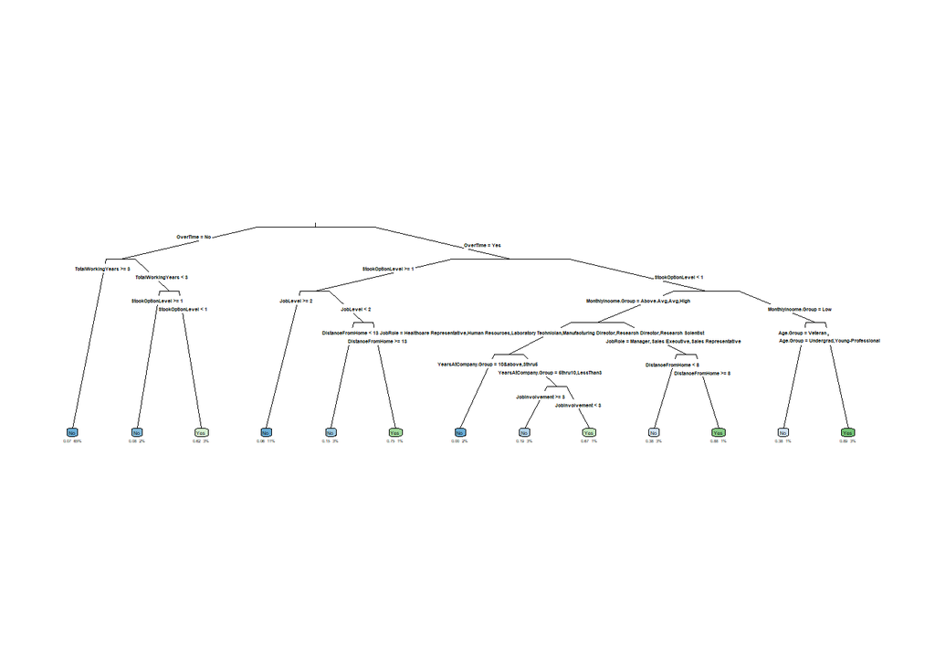

```r
set.seed(31) # I like to use prime numbers as seeds. IDK why. Just like 'em

library(rpart.plot)

DTModel <-rpart(formula = Attrition ~., data = training, method = 'class')
rpart.plot(DTModel, type = 3, clip.right.labs = FALSE, branch = .3, under = TRUE )
```

```r
rpart.rules(DTModel, style = "tall")
```

```
## Attrition is 0.00 when
##     OverTime is Yes
##     StockOptionLevel < 1
##     MonthlyIncome.Group is Above.Avg or Avg or High
##     JobRole is Healthcare Representative or Human Resources or Laboratory Technician or Manufacturing Director or Research Director or Research Scientist
##     YearsAtCompany.Group is 10&above or 3thru5
##
## Attrition is 0.06 when
##     OverTime is Yes
##     StockOptionLevel >= 1
##     JobLevel >= 2
##
## Attrition is 0.07 when
##     OverTime is No
##     TotalWorkingYears >= 3
##
## Attrition is 0.08 when
##     OverTime is No
##     StockOptionLevel >= 1
##     TotalWorkingYears < 3
##
## Attrition is 0.15 when
##     OverTime is Yes
##     StockOptionLevel >= 1
##     DistanceFromHome < 13
##     JobLevel < 2
##
## Attrition is 0.19 when
##     OverTime is Yes
##     StockOptionLevel < 1
##     MonthlyIncome.Group is Above.Avg or Avg or High
##     JobRole is Healthcare Representative or Human Resources or Laboratory Technician or Manufacturing Director or Research Director or Research Scientist
##     YearsAtCompany.Group is 5thru10 or LessThan3
##     JobInvolvement >= 3
##
## Attrition is 0.38 when
##     OverTime is Yes
##     StockOptionLevel < 1
##     MonthlyIncome.Group is Above.Avg or Avg or High
##     JobRole is Manager or Sales Executive or Sales Representative
```

[output cut: 24 more lines]

```
##     DistanceFromHome >= 13
##     JobLevel < 2
##
## Attrition is 0.88 when
##     OverTime is Yes
##     StockOptionLevel < 1
##     MonthlyIncome.Group is Above.Avg or Avg or High
##     JobRole is Manager or Sales Executive or Sales Representative
##     DistanceFromHome >= 8
##
## Attrition is 0.89 when
##     OverTime is Yes
##     StockOptionLevel < 1
##     MonthlyIncome.Group is Low
##     Age.Group is Undergrad or Young-Professional
```

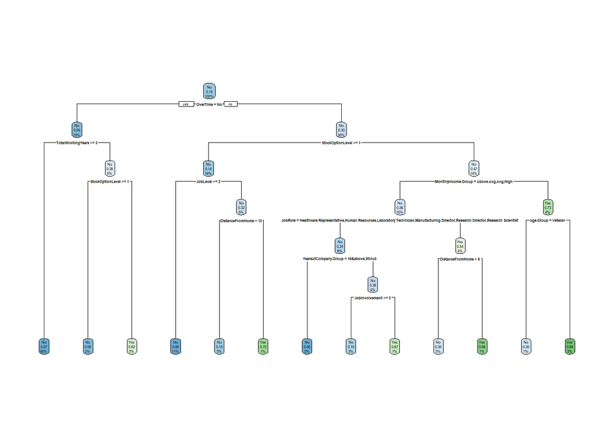

```r
rpart.plot(DTModel)
```

```r
DTModel_pred = predict(DTModel, newdata = test[-1], type = 'class')
# confusion matrix
DTM.CM <- confusionMatrix(DTModel_pred, as.factor(test$Attrition))
#notice I'm saving my confusion matrixes as an object with a standard name this will be important for us to compare our models at the end
DTM.CM
```

```
## Confusion Matrix and Statistics
##
##           Reference
## Prediction  No Yes
##        No  201  30
##        Yes  14  16
##
##                Accuracy : 0.8314
##                  95% CI : (0.7804, 0.8748)
##     No Information Rate : 0.8238
##     P-Value [Acc > NIR] : 0.41022
##
##                   Kappa : 0.3275
##
##  Mcnemar's Test P-Value : 0.02374
##
##             Sensitivity : 0.9349
##             Specificity : 0.3478
##          Pos Pred Value : 0.8701
##          Neg Pred Value : 0.5333
##              Prevalence : 0.8238
##          Detection Rate : 0.7701
##    Detection Prevalence : 0.8851
##       Balanced Accuracy : 0.6414
##
##        'Positive' Class : No
##
```

#~~~~~~~~~~~~~~~~~~~~~~~~~~~~~~~~~~~~~~~~~~~~~~~~~~~~~~~~~~~~~~~~~~~~~~~~~~~~~~~ # 3. KNN Model #~~~~~~~~~~~~~~~~~~~~~~~~~~~~~~~~~~~~~~~~~~~~~~~~~~~~~~~~~~~~~~~~~~~~~~~~~~~~~~~

```r
set.seed(31) #get that prime number ready

#Fit the model on train data
KnnModel <- train(Attrition~.,training, method = 'knn')
    #trControl = trainControl(method = 'repeatedcv', number = 3))

#Predict with test set
Knn.pred <- predict(KnnModel, test[-1])
#Print confusion matrix
Knn.CM <- confusionMatrix(Knn.pred, as.factor(test$Attrition))
Knn.CM
```

```
## Confusion Matrix and Statistics
##
##           Reference
## Prediction  No Yes
##        No  209  43
##        Yes   6   3
##
##                Accuracy : 0.8123
##                  95% CI : (0.7595, 0.8578)
##     No Information Rate : 0.8238
##     P-Value [Acc > NIR] : 0.7192
##
##                   Kappa : 0.0546
##
##  Mcnemar's Test P-Value : 2.706e-07
##
##             Sensitivity : 0.97209
##             Specificity : 0.06522
##          Pos Pred Value : 0.82937
##          Neg Pred Value : 0.33333
##              Prevalence : 0.82375
##          Detection Rate : 0.80077
##    Detection Prevalence : 0.96552
##       Balanced Accuracy : 0.51866
##
##        'Positive' Class : No
##
```

#~~~~~~~~~~~~~~~~~~~~~~~~~~~~~~~~~~~~~~~~~~~~~~~~~~~~~~~~~~~~~~~~~~~~~~~~~~~~~~~ # Hyper Parameter tunning #~~~~~~~~~~~~~~~~~~~~~~~~~~~~~~~~~~~~~~~~~~~~~~~~~~~~~~~~~~~~~~~~~~~~~~~~~~~~~~~

```r
#using the class package to have more control

library(class)
library(caret)
library(dplyr)
```